# effMaxSG on the prevalence-30% cells: constructions across the p30sg cells

- Show All Code
- Hide All Code
- View Source

Naive, MR (IJ two-term), MR (IJ winner-only) and MR (field) for both blocks, and the joint pair, under the effMaxSG identifier (TASK_p30_effMaxSG_2026-09-06)

Author

Larry León

Published

September 7, 2026

The four `p30sg` cells are the `p30` cells (harm planted in `{er ≤ q₀.₆₀(er)} ∩ {meno = 0}`, prevalence 0.3065) re-run on identical data under the `effMaxSG` identifier — the largest subgroup within 10% of the maximal effect among the consistency-qualifying candidates — in place of `maxeffCons` (the effect argmax). Constructions: naive and oracle as references, MR (IJ, two-term), MR (IJ, winner-only), MR (field), and the joint pair; the winner-floor variant is excluded. Displays use the Gaussian bookkeeping reference (harm block: lower bound, $\Phi(z_{0.95} r - b)$; complement block: upper bound, $\Phi(z_{0.95} r + b)$).

# 1 Knobs

```r
library(forestsearch)
library(ggplot2)
library(kableExtra)
`%||%` <- function(a, b) if (is.null(a) || length(a) == 0 || all(is.na(a))) b else a
globs <- strsplit(Sys.getenv("FS_SUMSG_GLOBS",
                  "results/fs_effMaxSG_*_z1q60_p30sg_combined_1_2000.rds"),
                  ";", fixed = TRUE)[[1]]
estimators <- c("naive", "mr", "mr_w", "fld")
curves     <- c(1, 1.25, 1.5, 2)
cell_label <- function(meta, f) {
  hr <- meta$target_hr_harm
  base <- if (hr < 1) sprintf("protective %.2f", hr)
  else if (hr == 1) "null 1.0" else sprintf("harm %.4g", hr)
  base <- paste0(base, sprintf(", prev %.0f%%", 100 * (meta$harm_prevalence_super %||% NA)))
  kn <- as.integer(sub("^.*_knoise(\\d+)_.*$", "\\1", basename(f)))
  nn <- if (meta$n_sample == 500) if (kn > 0 || hr < 1) "" else ", n=500" else sprintf(", n=%d", meta$n_sample)
  paste0(base, nn, if (kn > 0) sprintf(", %d noise", kn) else "")
}
files <- sort(unlist(lapply(globs, Sys.glob)))
stopifnot(length(files) > 0)
bundles <- lapply(files, readRDS)
labels  <- mapply(cell_label, lapply(bundles, `[[`, "meta"), files)
```

# 2 Complement block (one-sided = upper bound)

```r
tabC <- do.call(rbind, lapply(seq_along(bundles), function(i) {
  s <- fs_sim_bias_coverage(bundles[[i]]$results, block = "Hc", estimators = estimators, side = "upper")
  s$cell <- labels[i]; s
}))
tabC$estimator <- factor(tabC$estimator, levels = c("naive", "mr", "mr_w", "fld"),
                         labels = c("naive", "IJ two-term", "IJ winner-only", "field"))
kbl(tabC[, c("cell", "estimator", "n", "b", "r", "cov1", "cov1_wilson_lo", "cov1_wilson_hi",
             "cov2", "cov2_wilson_lo", "cov2_wilson_hi", "cov1_ref", "cov2_ref")],
    digits = 3, booktabs = TRUE, row.names = FALSE,
    caption = "Complement block; cov1 = one-sided 95% UPPER-bound coverage of beta(Hhat^c).") |>
  kable_styling(font_size = 12)
```

Complement block; cov1 = one-sided 95% UPPER-bound coverage of beta(Hhat^c).

| cell | estimator | n | b | r | cov1 | cov1_wilson_lo | cov1_wilson_hi | cov2 | cov2_wilson_lo | cov2_wilson_hi | cov1_ref | cov2_ref |
| --- | --- | --- | --- | --- | --- | --- | --- | --- | --- | --- | --- | --- |
| null 1.0, prev 31%, n=1000 | naive | 1909 | -0.862 | 0.998 | 0.799 | 0.781 | 0.817 | 0.883 | 0.867 | 0.896 | 0.782 | 0.861 |
| null 1.0, prev 31%, n=1000 | IJ two-term | 1909 | -0.277 | 1.829 | 0.997 | 0.994 | 0.999 | 1.000 | 0.998 | 1.000 | 0.997 | 0.999 |
| null 1.0, prev 31%, n=1000 | IJ winner-only | 1909 | -0.277 | 0.886 | 0.888 | 0.873 | 0.901 | 0.917 | 0.903 | 0.928 | 0.881 | 0.906 |
| null 1.0, prev 31%, n=1000 | field | 1909 | -0.155 | 0.956 | 0.932 | 0.920 | 0.942 | 0.944 | 0.933 | 0.953 | 0.922 | 0.936 |
| null 1.0, prev 31%, n=500 | naive | 1841 | -0.954 | 1.029 | 0.769 | 0.749 | 0.787 | 0.865 | 0.849 | 0.880 | 0.770 | 0.855 |
| null 1.0, prev 31%, n=500 | IJ two-term | 1841 | -0.354 | 1.852 | 0.997 | 0.993 | 0.999 | 0.999 | 0.997 | 1.000 | 0.996 | 0.999 |
| null 1.0, prev 31%, n=500 | IJ winner-only | 1841 | -0.354 | 0.893 | 0.866 | 0.850 | 0.881 | 0.908 | 0.894 | 0.920 | 0.867 | 0.901 |
| null 1.0, prev 31%, n=500 | field | 1841 | -0.235 | 0.971 | 0.911 | 0.897 | 0.923 | 0.941 | 0.929 | 0.951 | 0.913 | 0.936 |
| harm 1.5, prev 31%, n=500 | naive | 1999 | -0.762 | 0.926 | 0.793 | 0.775 | 0.810 | 0.867 | 0.852 | 0.882 | 0.777 | 0.849 |
| harm 1.5, prev 31%, n=500 | IJ two-term | 1999 | -0.278 | 1.704 | 0.996 | 0.993 | 0.998 | 0.999 | 0.997 | 1.000 | 0.994 | 0.999 |
| harm 1.5, prev 31%, n=500 | IJ winner-only | 1999 | -0.278 | 0.818 | 0.869 | 0.853 | 0.883 | 0.901 | 0.888 | 0.914 | 0.857 | 0.877 |
| harm 1.5, prev 31%, n=500 | field | 1999 | -0.194 | 0.888 | 0.913 | 0.900 | 0.925 | 0.937 | 0.926 | 0.947 | 0.897 | 0.913 |
| harm 1.75, prev 31%, n=500 | naive | 1999 | -0.645 | 0.896 | 0.819 | 0.801 | 0.835 | 0.882 | 0.867 | 0.895 | 0.797 | 0.859 |
| harm 1.75, prev 31%, n=500 | IJ two-term | 1999 | -0.212 | 1.650 | 0.996 | 0.993 | 0.998 | 1.000 | 0.998 | 1.000 | 0.994 | 0.998 |
| harm 1.75, prev 31%, n=500 | IJ winner-only | 1999 | -0.212 | 0.790 | 0.881 | 0.866 | 0.894 | 0.908 | 0.894 | 0.920 | 0.862 | 0.870 |
| harm 1.75, prev 31%, n=500 | field | 1999 | -0.145 | 0.858 | 0.919 | 0.906 | 0.930 | 0.935 | 0.923 | 0.945 | 0.897 | 0.904 |

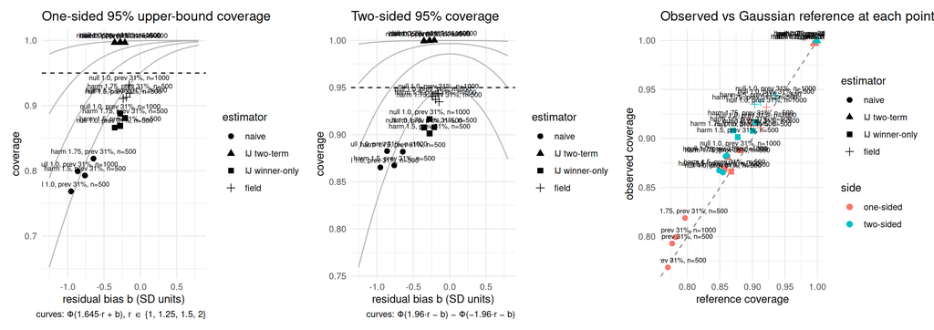

```r
fs_plot_bias_coverage(tabC, curves = curves, side = "upper")
```

# 3 Harm block (one-sided = lower bound)

```r
tabH <- do.call(rbind, lapply(seq_along(bundles), function(i) {
  s <- fs_sim_bias_coverage(bundles[[i]]$results, block = "H", estimators = estimators, side = "lower")
  s$cell <- labels[i]; s
}))
tabH$estimator <- factor(tabH$estimator, levels = c("naive", "mr", "mr_w", "fld"),
                         labels = c("naive", "IJ two-term", "IJ winner-only", "field"))
kbl(tabH[, c("cell", "estimator", "n", "b", "r", "cov1", "cov1_wilson_lo", "cov1_wilson_hi",
             "cov2", "cov2_wilson_lo", "cov2_wilson_hi", "cov1_ref", "cov2_ref")],
    digits = 3, booktabs = TRUE, row.names = FALSE,
    caption = "Harm block; cov1 = one-sided 95% LOWER-bound coverage of beta(Hhat).") |>
  kable_styling(font_size = 12)
```

Harm block; cov1 = one-sided 95% LOWER-bound coverage of beta(Hhat).

| cell | estimator | n | b | r | cov1 | cov1_wilson_lo | cov1_wilson_hi | cov2 | cov2_wilson_lo | cov2_wilson_hi | cov1_ref | cov2_ref |
| --- | --- | --- | --- | --- | --- | --- | --- | --- | --- | --- | --- | --- |
| null 1.0, prev 31%, n=1000 | naive | 1909 | 3.062 | 1.363 | 0.192 | 0.175 | 0.210 | 0.357 | 0.336 | 0.379 | 0.206 | 0.348 |
| null 1.0, prev 31%, n=1000 | IJ two-term | 1909 | 0.586 | 1.459 | 0.969 | 0.960 | 0.976 | 0.991 | 0.985 | 0.994 | 0.965 | 0.988 |
| null 1.0, prev 31%, n=1000 | IJ winner-only | 1909 | 0.586 | 0.596 | 0.663 | 0.641 | 0.684 | 0.664 | 0.642 | 0.685 | 0.653 | 0.680 |
| null 1.0, prev 31%, n=1000 | field | 1909 | 0.235 | 1.128 | 0.946 | 0.935 | 0.955 | 0.962 | 0.953 | 0.970 | 0.947 | 0.969 |
| null 1.0, prev 31%, n=500 | naive | 1841 | 3.710 | 1.598 | 0.127 | 0.112 | 0.143 | 0.288 | 0.268 | 0.310 | 0.140 | 0.281 |
| null 1.0, prev 31%, n=500 | IJ two-term | 1841 | 0.701 | 1.670 | 0.978 | 0.971 | 0.984 | 0.991 | 0.986 | 0.995 | 0.980 | 0.995 |
| null 1.0, prev 31%, n=500 | IJ winner-only | 1841 | 0.701 | 0.711 | 0.682 | 0.661 | 0.703 | 0.745 | 0.724 | 0.764 | 0.681 | 0.738 |
| null 1.0, prev 31%, n=500 | field | 1841 | 0.260 | 1.303 | 0.971 | 0.963 | 0.978 | 0.985 | 0.978 | 0.989 | 0.970 | 0.987 |
| harm 1.5, prev 31%, n=500 | naive | 1999 | 2.478 | 1.299 | 0.381 | 0.360 | 0.402 | 0.542 | 0.520 | 0.564 | 0.367 | 0.527 |
| harm 1.5, prev 31%, n=500 | IJ two-term | 1999 | 0.260 | 1.408 | 0.978 | 0.971 | 0.984 | 0.983 | 0.976 | 0.988 | 0.980 | 0.993 |
| harm 1.5, prev 31%, n=500 | IJ winner-only | 1999 | 0.260 | 0.611 | 0.744 | 0.725 | 0.763 | 0.701 | 0.680 | 0.721 | 0.772 | 0.754 |
| harm 1.5, prev 31%, n=500 | field | 1999 | -0.009 | 1.123 | 0.970 | 0.962 | 0.977 | 0.938 | 0.927 | 0.948 | 0.968 | 0.972 |
| harm 1.75, prev 31%, n=500 | naive | 1999 | 2.120 | 1.224 | 0.474 | 0.452 | 0.496 | 0.624 | 0.602 | 0.645 | 0.458 | 0.610 |
| harm 1.75, prev 31%, n=500 | IJ two-term | 1999 | 0.133 | 1.337 | 0.982 | 0.975 | 0.987 | 0.977 | 0.969 | 0.983 | 0.981 | 0.991 |
| harm 1.75, prev 31%, n=500 | IJ winner-only | 1999 | 0.133 | 0.588 | 0.770 | 0.751 | 0.788 | 0.680 | 0.659 | 0.700 | 0.798 | 0.747 |
| harm 1.75, prev 31%, n=500 | field | 1999 | -0.079 | 1.079 | 0.964 | 0.955 | 0.972 | 0.932 | 0.921 | 0.943 | 0.968 | 0.965 |

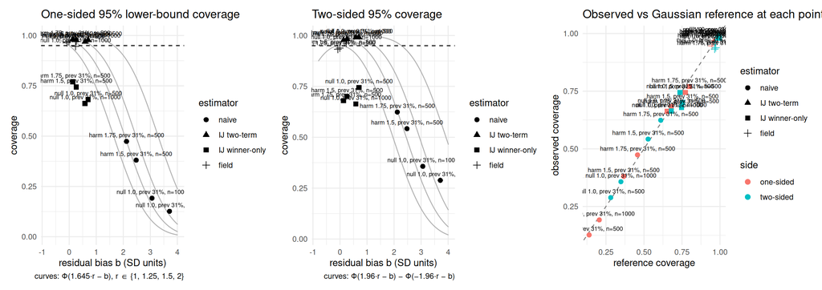

```r
fs_plot_bias_coverage(tabH, curves = curves, side = "lower")
```

# 4 The simultaneous pair

```r
wil <- function(x, n, z = qnorm(.975)) { c <- (x + z^2/(2*n))/(1+z^2/n); h <- z*sqrt(x*(1-x)/n + z^2/(4*n^2))/(1+z^2/n); c(c - h, c + h) }
tabJ <- do.call(rbind, lapply(seq_along(bundles), function(i) {
  r <- bundles[[i]]$results; d <- r[r$detected %in% 1L, ]
  d <- d[is.finite(d$betaHhat_H) & is.finite(d$betaHhat_Hc) & is.finite(d$fld_joint_gamma), ]
  pairs <- list(`separate 95%` = list(lo = d$fld_H_lo1s, up = d$fld_Hc_up1s),
                `Bonferroni`   = list(lo = d$fld_joint_bonf_loH, up = d$fld_joint_bonf_upHc),
                `calibrated`   = list(lo = d$fld_joint_loH, up = d$fld_joint_upHc))
  do.call(rbind, lapply(names(pairs), function(nm) { p <- pairs[[nm]]
    cH <- d$betaHhat_H >= p$lo; cC <- d$betaHhat_Hc <= p$up; jc <- mean(cH & cC); w <- wil(jc, nrow(d))
    data.frame(cell = labels[i], pair = nm, n = nrow(d), joint_cov = jc, wilson_lo = w[1], wilson_hi = w[2],
               cov_H = mean(cH), cov_Hc = mean(cC),
               margin_H = mean(log(d$mr_H_est) - log(p$lo)), margin_Hc = mean(log(p$up) - log(d$mr_Hc_est)),
               mean_gamma = mean(d$fld_joint_gamma), mean_corr = mean(d$fld_joint_corr), stringsAsFactors = FALSE) }))
}))
kbl(tabJ, digits = 3, booktabs = TRUE, row.names = FALSE,
    caption = "Joint coverage of (beta(Hhat) >= lower_H, beta(Hhat^c) <= upper_Hc) with Wilson intervals; margins on the log scale from the two-term de-biased estimates.") |>
  kable_styling(font_size = 12)
```

Joint coverage of (beta(Hhat) >= lower_H, beta(Hhat^c) <= upper_Hc) with Wilson intervals; margins on the log scale from the two-term de-biased estimates.

| cell | pair | n | joint_cov | wilson_lo | wilson_hi | cov_H | cov_Hc | margin_H | margin_Hc | mean_gamma | mean_corr |
| --- | --- | --- | --- | --- | --- | --- | --- | --- | --- | --- | --- |
| null 1.0, prev 31%, n=1000 | separate 95% | 1909 | 0.881 | 0.865 | 0.894 | 0.946 | 0.932 | 0.508 | 0.166 | 0.025 | 0.074 |
| null 1.0, prev 31%, n=1000 | Bonferroni | 1909 | 0.938 | 0.926 | 0.948 | 0.975 | 0.963 | 0.612 | 0.196 | 0.025 | 0.074 |
| null 1.0, prev 31%, n=1000 | calibrated | 1909 | 0.938 | 0.926 | 0.948 | 0.975 | 0.963 | 0.611 | 0.195 | 0.025 | 0.074 |
| null 1.0, prev 31%, n=500 | separate 95% | 1841 | 0.884 | 0.869 | 0.898 | 0.971 | 0.911 | 0.697 | 0.236 | 0.025 | 0.073 |
| null 1.0, prev 31%, n=500 | Bonferroni | 1841 | 0.942 | 0.931 | 0.952 | 0.992 | 0.951 | 0.841 | 0.278 | 0.025 | 0.073 |
| null 1.0, prev 31%, n=500 | calibrated | 1841 | 0.942 | 0.931 | 0.952 | 0.992 | 0.951 | 0.841 | 0.278 | 0.025 | 0.073 |
| harm 1.5, prev 31%, n=500 | separate 95% | 1999 | 0.884 | 0.870 | 0.898 | 0.970 | 0.913 | 0.664 | 0.229 | 0.025 | 0.046 |
| harm 1.5, prev 31%, n=500 | Bonferroni | 1999 | 0.940 | 0.929 | 0.950 | 0.988 | 0.952 | 0.803 | 0.271 | 0.025 | 0.046 |
| harm 1.5, prev 31%, n=500 | calibrated | 1999 | 0.939 | 0.928 | 0.949 | 0.987 | 0.951 | 0.802 | 0.271 | 0.025 | 0.046 |
| harm 1.75, prev 31%, n=500 | separate 95% | 1999 | 0.886 | 0.871 | 0.899 | 0.964 | 0.919 | 0.651 | 0.227 | 0.025 | 0.028 |
| harm 1.75, prev 31%, n=500 | Bonferroni | 1999 | 0.940 | 0.929 | 0.950 | 0.987 | 0.952 | 0.788 | 0.269 | 0.025 | 0.028 |
| harm 1.75, prev 31%, n=500 | calibrated | 1999 | 0.940 | 0.929 | 0.950 | 0.987 | 0.952 | 0.787 | 0.268 | 0.025 | 0.028 |

# 5 Reading

Complement, one-sided upper coverage: naive 0.799/0.769/0.793/0.819 (r = 1.00/1.03/0.93/0.90); IJ two-term 0.997/0.997/0.996/0.996 (r = 1.83/1.85/1.70/1.65); IJ winner-only 0.888/0.866/0.869/0.881 (r = 0.89/0.89/0.82/0.79); field 0.932/0.911/0.913/0.919 (r = 0.96/0.97/0.89/0.86). Harm, one-sided lower coverage: naive 0.192/0.127/0.381/0.474; IJ two-term 0.969/0.978/0.978/0.982 (r = 1.46/1.67/1.41/1.34); IJ winner-only 0.663/0.682/0.744/0.770 (r = 0.60/0.71/0.61/0.59); field 0.946/0.971/0.970/0.964 (r = 1.13/1.30/1.12/1.08). Joint pair: calibrated coverage 0.938/0.942/0.939/0.940 (mean gamma 0.0251/0.0251/0.0251/0.0251, mean corr +0.074/+0.073/+0.046/+0.028) vs Bonferroni 0.938/0.942/0.940/0.940 vs separate 95% bounds 0.881/0.884/0.884/0.886.